# Toxicity Analysis

Casey Bray

2022-11-25

Toxic Dataset: “https://archive-beta.ics.uci.edu/dataset/728/toxicity-2”

```r
## Read in dataset to variable "toxic".
toxic <- read.csv("toxicity_data.csv")

## Create a backup of "toxic" dataset.
toxic_copy1 <- toxic
```

```r
## Quick review of target variable, "Class", shows that NonToxic is 2:1 to Toxic.
toxic %>%
  count(Class)
```

```
##      Class   n
## 1 NonToxic 115
## 2    Toxic  56
```

Due to the relative size of this dataset, 1204 variables, it is necessary to do some sort of feature selection first to reduce the dataset to a consumable chunk of data.

– Recursive Feature Elimination: Also called ‘RFE’, is an algorithm used to select features that accuractely predict a ‘target’ variable in prediction models. RFE utilizes a backward selection process to select features. The steps are as follows:

1. Builds model & calculates importance of all features(except ‘target’).
2. Rank-orders features and removes ones with least importance one-by-one based on model eval metrics(RMSE,accuracy,kappa).
3. Repeats process until a *smaller* set of features is achieved.

** Model can select ALL features. ** Feature selection can also be based on model or criterion(e.g., accuracy).

```r
## First, we need to split data into train/test sets.
sample <- sample(c(TRUE,FALSE), nrow(toxic), replace = TRUE, prob=c(0.7,0.3))
train <- toxic[sample, ]
test <- toxic[!sample, ]

## Define our recursive feature elimination
control_rfe = rfeControl(functions = rfFuncs, # random forest
                      method = "repeatedcv", # repeated cv
                      repeats = 5, # number of repeats
                      number = 10) # number of folds

set.seed(50) ## for reproducibility

# Performing RFE, this may take some time
result_rfe = rfe(x = train[,-1204],
                 y = as.factor(unlist(train[,1204])),
                 sizes = c(1:15),
                 rfeControl = control_rfe)


print(result_rfe)
```

```
##
## Recursive feature selection
##
## Outer resampling method: Cross-Validated (10 fold, repeated 5 times)
##
## Resampling performance over subset size:
##
##  Variables Accuracy    Kappa AccuracySD KappaSD Selected
##          1   0.5779  0.02017    0.12951  0.2750
##          2   0.6311  0.07703    0.11973  0.2709
##          3   0.6249  0.03855    0.11865  0.2624
##          4   0.6292  0.07867    0.12080  0.2657
##          5   0.6356  0.08012    0.12759  0.2896
##          6   0.6404  0.08386    0.12799  0.2901
##          7   0.6374  0.07743    0.12986  0.2857
##          8   0.6367  0.06442    0.12236  0.2820
##          9   0.6451  0.09426    0.12554  0.2857        *
##         10   0.6434  0.08897    0.11441  0.2647
##         11   0.6298  0.04727    0.10997  0.2472
##         12   0.6366  0.04256    0.09614  0.2344
##         13   0.6376  0.04715    0.10131  0.2598
##         14   0.6269  0.02773    0.10457  0.2374
##         15   0.6294  0.02508    0.09456  0.2124
##       1203   0.6255 -0.06229    0.08993  0.1839
##
## The top 5 variables (out of 9):
##    SpMAD_Dt, ATSC7i, Mp, AATS0p, MATS6c
```

```r
## Show our selected features.
predictors(result_rfe)
```

```
## [1] "SpMAD_Dt"  "ATSC7i"    "Mp"        "AATS0p"    "MATS6c"    "EE_Dt"
## [7] "SpDiam_Dt" "SpMax_Dt"  "SpAD_Dt"
```

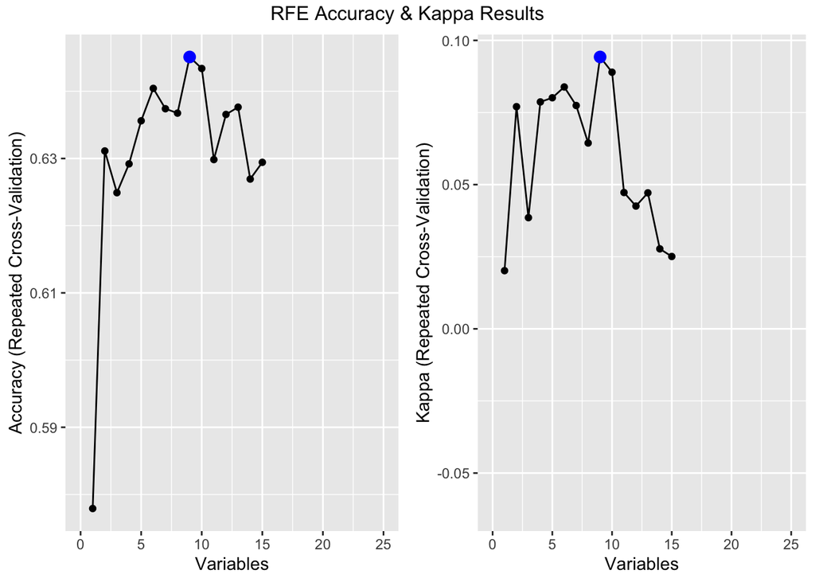

```r
## Provide a visual version of the selected features. I have subsetted the
## results as the before graph was very difficult to interpret.
plt1 <- ggplot(data = result_rfe, metric = "Accuracy") + xlim(0,25)
plt2 <- ggplot(data = result_rfe, metric = "Kappa") + xlim(0,25)

grid.arrange(plt1,plt2,ncol=2,top="RFE Accuracy & Kappa Results")
```

```r
## Let's first subset the data with our chosen features.
final_toxic <- select(toxic,"MATS6c","MDEC.23","SpMax3_Bhm","ZMIC1","WTPT.5",
                      "AATSC2e","GATS5c","ATSC3v","Class")

## Preview our new data.
str(final_toxic)
```

```
## 'data.frame':    171 obs. of  9 variables:
##  $ MATS6c    : num  -0.0902 -0.0442 0.3483 0.171 -0.0489 ...
##  $ MDEC.23   : num  60.2 44.5 37.5 40.6 52.7 ...
##  $ SpMax3_Bhm: num  4.04 3.85 3.83 3.86 3.89 ...
##  $ ZMIC1     : num  111.9 101.1 73.3 75.2 90.2 ...
##  $ WTPT.5    : num  0 19.4 27.9 24.7 19.7 ...
##  $ AATSC2e   : num  0.0076 0.0279 0.0117 0.008 0.0156 0.006 0.0127 0.0058 0.017 0.0115 ...
##  $ GATS5c    : num  1.18 1.08 1.61 1.41 1.08 ...
##  $ ATSC3v    : num  575.4 135 11.2 -168.1 94.5 ...
##  $ Class     : chr  "NonToxic" "NonToxic" "NonToxic" "NonToxic" ...
```

Feature Exploration:

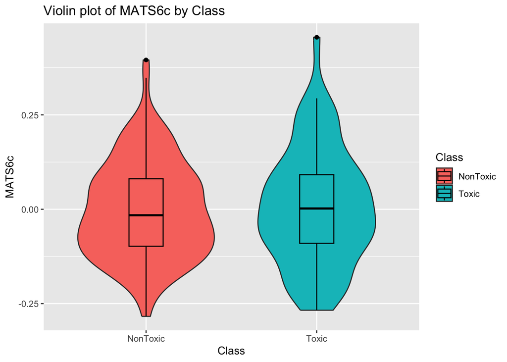

```r
## MATS6c evaluation
ggplot(final_toxic, aes(x=Class, y=MATS6c, fill=Class, trim=FALSE)) +
  geom_violin(width=0.8) +
  geom_boxplot(width=0.2,color='black') +
  ggtitle("Violin plot of MATS6c by Class")
```

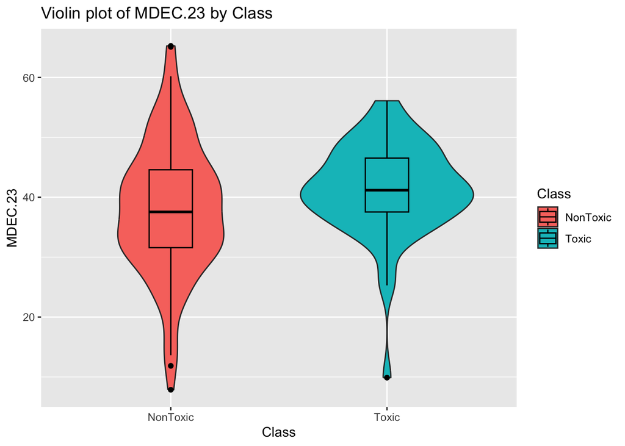

```r
## MDEC.23 evaluation
ggplot(final_toxic, aes(x=Class, y=MDEC.23, fill=Class, trim=FALSE)) +
  geom_violin(width=0.8) +
  geom_boxplot(width=0.2,color='black') +
  ggtitle("Violin plot of MDEC.23 by Class")
```

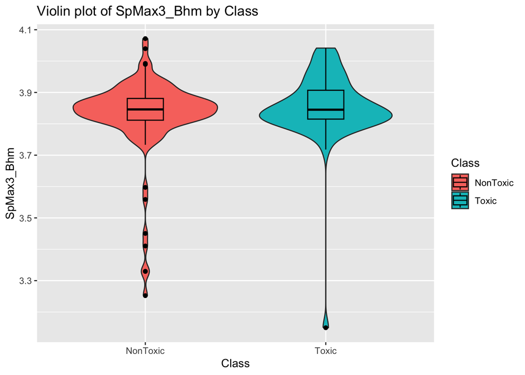

```r
## SpMax3_Bhm evaluation
ggplot(final_toxic, aes(x=Class, y=SpMax3_Bhm, fill=Class, trim=FALSE)) +
  geom_violin(width=0.8) +
  geom_boxplot(width=0.2,color='black') +
  ggtitle("Violin plot of SpMax3_Bhm by Class")
```

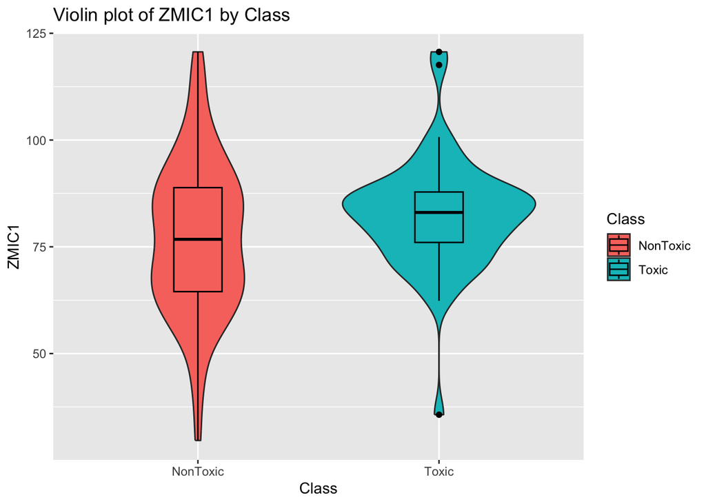

```r
## ZMIC1 evaluation
ggplot(final_toxic, aes(x=Class, y=ZMIC1, fill=Class, trim=FALSE)) +
  geom_violin(width=0.8) +
  geom_boxplot(width=0.2,color='black') +
  ggtitle("Violin plot of ZMIC1 by Class")
```

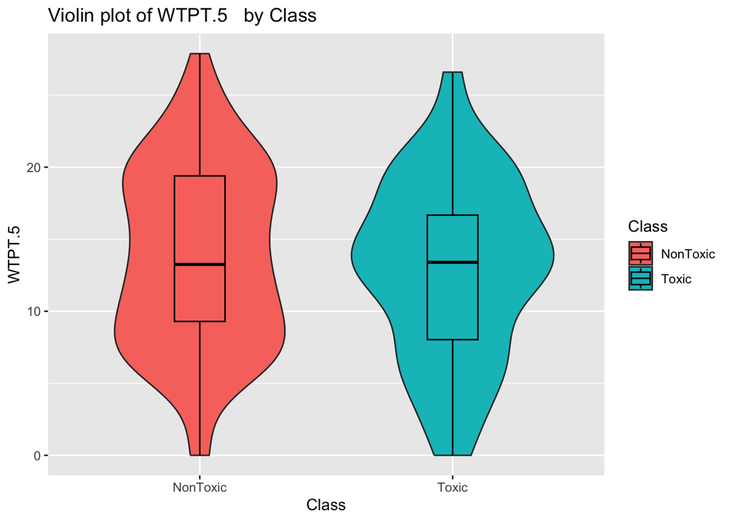

```r
## WTPT.5 evaluation
ggplot(final_toxic, aes(x=Class, y=WTPT.5  , fill=Class, trim=FALSE)) +
  geom_violin(width=0.8) +
  geom_boxplot(width=0.2,color='black') +
  ggtitle("Violin plot of WTPT.5   by Class")
```

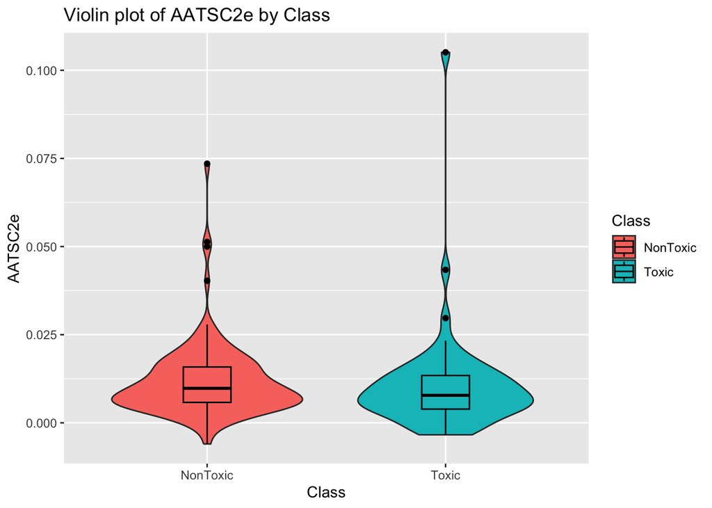

```r
## AATSC2e evaluation
ggplot(final_toxic, aes(x=Class, y=AATSC2e, fill=Class, trim=FALSE)) +
  geom_violin(width=0.8) +
  geom_boxplot(width=0.2,color='black') +
  ggtitle("Violin plot of AATSC2e by Class")
```

– MATS6c appears to have a much wider distribution compared to non-toxic. However, median values appear to be quite similar. Although, Toxic median comes out just a shade higher! Neither show a normal distribution and have apparent tails on the high end.

– MDEC.23 shows quite a visible difference between Toxic median and Non-Toxic median! Toxic also shows a much more narrow distribution and fewer outliers.

– ZMIC1 shows a very spread out distribution for both Classes. On a positive note, Toxic shows what appears to be a very significantly different median from Non-Toxic. Toxic also presents a much larger lower quartile and significant outliers.

– WTPT.5 appears to show similar medians for both classes. Toxic shows a larger lower quartile while Non-Toxic shows a large Upper quartile. Both Classes have a very large distribution.

– AATSC2e shows both classes have a very narrow distrbution. Non-Toxic has a slightly higher median value. Toxic has a very large outlier. However, we have no way to verify this is a typo or not.

Decision Tree:

```r
train_control <- trainControl(method = "LOOCV")

set.seed(42)
sample <- sample(c(TRUE,FALSE), nrow(final_toxic), replace = TRUE, prob=c(0.7,0.3))
train_toxic <- final_toxic[sample, ]
test_toxic <- final_toxic[!sample, ]


dim(train_toxic)
```

```
## [1] 112   9
```

```r
dim(test_toxic)
```

```
## [1] 59  9
```

```r
## Decision Tree using "Caret"
toxic.tree = train(Class ~ .,
                  data=train_toxic,
                  method="rpart",
                  trControl = train_control)

print(toxic.tree)
```

```
## CART
##
## 112 samples
##   8 predictor
##   2 classes: 'NonToxic', 'Toxic'
##
## No pre-processing
## Resampling: Leave-One-Out Cross-Validation
## Summary of sample sizes: 111, 111, 111, 111, 111, 111, ...
## Resampling results across tuning parameters:
##
##   cp          Accuracy   Kappa
##   0.02857143  0.6785714   0.24010554
##   0.08571429  0.6160714   0.02272727
##   0.12857143  0.5535714  -0.23076923
##
## Accuracy was used to select the optimal model using the largest value.
## The final value used for the model was cp = 0.02857143.
```

```r
toxic.pred <- predict(toxic.tree, newdata = test_toxic)

cat("\nPrediction Table: ")
```

```
##
## Prediction Table:
```

```r
table(toxic.pred, test_toxic$Class)
```

```
##
## toxic.pred NonToxic Toxic
##   NonToxic       30    15
##   Toxic           8     6
```

```r
cat("\nError Rate: ")
```

```
##
## Error Rate:
```

```r
round(mean(toxic.pred != test_toxic$Class),2)
```

```
## [1] 0.39
```

[figure not shown]

```r
suppressMessages(library(rattle))

fancyRpartPlot(toxic.tree$finalModel)
```

Random Forest:

```r
set.seed(55)
## Set our number of variables to be randomly collected
mtries <- sqrt(ncol(train_toxic))
grid <- expand.grid(.mtry=mtries)

## Assign random forest model to variable.
toxic.tree = train(Class ~ .,
                  data=train_toxic,
                  method="rf",
                  metric="Accuracy",
                  tuneGrid = grid,
                  trControl = train_control)

print(toxic.tree)
```

```
## Random Forest
##
## 112 samples
##   8 predictor
##   2 classes: 'NonToxic', 'Toxic'
##
## No pre-processing
## Resampling: Leave-One-Out Cross-Validation
## Summary of sample sizes: 111, 111, 111, 111, 111, 111, ...
## Resampling results:
##
##   Accuracy   Kappa
##   0.7053571  0.2235294
##
## Tuning parameter 'mtry' was held constant at a value of 3
```

```r
toxic.pred <- predict(toxic.tree, newdata = test_toxic)

cat("\nPrediction Table: ")
```

```
##
## Prediction Table:
```

```r
table(toxic.pred, test_toxic$Class)
```

```
##
## toxic.pred NonToxic Toxic
##   NonToxic       31    12
##   Toxic           7     9
```

```r
cat("\nError Rate: ")
```

```
##
## Error Rate:
```

```r
round(mean(toxic.pred != test_toxic$Class),2)
```

```
## [1] 0.32
```

Random Forest reduces test error from 0.39 to 0.32 — a 7-percentage-point absolute improvement over the single Decision Tree baseline.